# DeconvTest: simulation framework for quantifying errors and selecting optimal parameters of image deconvolution

Author: *Anna Medyukhina*

Affiliation: Research Group Applied Systems Biology - Head: Prof. Dr. Marc Thilo Figge  
https://www.leibniz-hki.de/en/applied-systems-biology.html  
HKI-Center for Systems Biology of Infection  
Leibniz Institute for Natural Product Research and Infection Biology -  
Hans Knöll Insitute (HKI)  
Adolf-Reichwein-Straße 23, 07745 Jena, Germany

DeconvTest is a Python-based simulation framework that allows the user to quantify and compare the performance of different deconvolution methods. The framework integrates all components needed for such quantitative comparison and consists of three main modules: (1) *in silico* microscopy, (2) deconvolution, and (3) performance quantification.

￼

[figure not shown]

## Source code

The source code of the package can be found at https://github.com/applied-systems-biology/DeconvTest

## Installation

1. Download [Fiji](https://fiji.sc/#download), make sure that the Fiji installation path does not contain spaces; note the Fiji installation path: you will have to provide it later when installing the DeconvTest packge
2. Download the [DeconvolutionLab_2.jar](http://bigwww.epfl.ch/deconvolution/deconvolutionlab2/) and [Iterative_Deconvolve_3D.class](https://imagej.net/Iterative_Deconvolve_3D) and copy them to the plugins folder of Fiji
3. Install python or [python Anaconda](https://www.anaconda.com/distribution/)
4. Download the [DeconvTest](https://github.com/applied-systems-biology/DeconvTest/releases) package, enter the package directory and install the package by running `python setup.py install`
5. Provide the path to Fiji when prompted

## Requirements

The software was tested with the following versions of the required packakges:

- scikit-image 0.15.0
- pandas 0.25.1
- numpy 1.16.5
- seaborn 0.9.0
- scipy 1.3.1
- ddt 1.2.1

## License

The source code of this framework is released under the [3-clause BSD license](https://github.com/applied-systems-biology/DeconvTest/blob/master/LICENSE)

# Simulation of microscopy experiments

Microscopic imaging of a sample involves illuminating the sample with a light source, collecting the emitted light, and discretizing the signal by recoding it in a detector, such as a CCD camera. This process can be represented as a continuous convolution of the sample with a point spread function (PSF) - the image of a point source - and subsequent discretization. Convolution of complex continuous signals is non-trivial to compute. Hence, when simulating this process on a computer, we represent the continuous convolution process by a convolution of discrete signals of high resolution (very small voxel size), while the process of discretization is simulated by the subsequent downsampling (decrease of the resolution).

￼

[figure not shown]

To simulate the whole microscopy process, we need to model the following steps and components:

1. Images of cells
2. Point spread function (PSF) of the imaging system
3. Convolution and downsampling
4. Noise

## Generating synthetic cells

Synthetic cells can be generated with the class `Cell`, which is initialized with the following parameters:

```python
from DeconvTest import Cell
print(Cell.__init__.__doc__)
```

```
        Initializes the cell image from a given list of indices or by reading from file.

        Parameters
        ----------
        filename: str, optional
            Path used to load the cell image.
            If None or non-existent, no image will be loaded.
            Default is None.
        ind : ndarray or list, optional
            3D coordinates of all pixels of the binary mask of the cell.
            The size of the first axis of the ndarray or the length of the list should be equal to
             the number of dimensions in the cell image (3 for 3D image).
            The size of the second axis of the ndarray or the length of each sublist corresponds to
             the number of pixels belonging to the cell mask.
        position : sequence of floats, optional
            Coordinates of the cell center in a multicellular stack in pixels.
            The length of the sequence should correspond to the number of dimensions in the cell image
             (3 for 3D image).
        input_voxel_size : scalar or sequence of scalars, optional
            Voxel size in z, y and x used to generate the cell image.
            If not None, a cell image will be generated with the give voxel size and cell parameters specified
             in `generate_kwargs`.
            Default is None.
        generate_kwargs : key, value pairings
            Keyword arguments passed to the `self.generate` function.
```

Cell of ellipsoidal, as well as realistic shapes can be generated:

```python
print(Cell.generate.__doc__)
```

```
        Generates a synthetic object image from given parameters and stores the output in the `self.image` variable.

        Parameters
        ----------
        input_voxel_size : scalar or sequence of scalars
            Voxel size in z, y and x used to generate the object image.
            If one value is provided, the voxel size is assumed to be equal along all axes.
        input_cell_kind : string, optional
            Name of the shape of the ground truth object from set of
            {ellipsoid, spiky_cell}.
            Default is 'ellipsoid'
        kwargs : key, value pairings
            Keyword arguments passed to corresponding methods to generate synthetic objects.
```

### Usage examples

##### Example 1

Generate a spherical cell with the diameter 10 µm and voxel size 0.3 µm per px and visualize its xy, xz, and yz maximum projections:

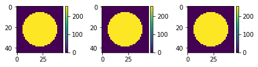

```python
cell = Cell(input_voxel_size=0.3,
            input_cell_kind='ellipsoid',
            size=10)
cell.show_2d_projections()
```

The `input_cell_kind` argument can be ommited in this case, because its default value is `ellipsoid`:

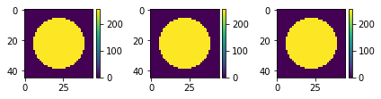

```python
cell = Cell(input_voxel_size=0.3,
            size=10)
cell.show_2d_projections()
```

##### Example 2

Generate a cell with ellipsoidal shape with axes 10, 7, and 7 µm and voxel size 0.3 µm per px:

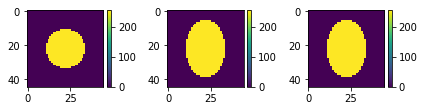

```python
cell = Cell(input_voxel_size=0.3,
            size=[10, 7, 7])
cell.show_2d_projections()
```

Visualize the cell in 3D using ipyvolume:

```python
import ipyvolume.pylab as p3
from IPython.core.display import HTML
p3.clear()
p3.plot_isosurface(cell.image)
p3.show()
```

##### Example 3

Generate a cell with ellipsoidal shape with axes 10, 7, and 7 µm and rotation of π/4 along the polar axis and π/2 along the azimuthal axis. Voxel size is 0.3 µm per px:

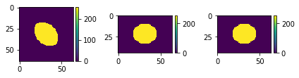

```python
import numpy as np
cell = Cell(input_voxel_size=0.3,
            size=[10, 7, 7],
            phi=np.pi/4,
            theta=np.pi/2)
cell.show_2d_projections()
```

The cell sizes can be alternatively specified by the arguments `size_x`, `size_y` and `size_z`:

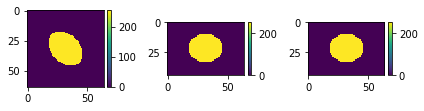

```python
cell = Cell(input_voxel_size=0.3,
            size_x=7,
            size_y=7,
            size_z=10,
            phi=np.pi/4,
            theta=np.pi/2)
cell.show_2d_projections()
```

##### Example 4

Generate a spiky cell with spikiness 0.5 (*i.e.*, 50% of cell surface covered by spikes), spike size 1 cell radius, and spike smoothness 0.05 (*i.e.*, the size of the smoothing filter equals to 5% of cell radius); the cell has ellipsoidal shape with axes 10, 7, and 7 µm and rotation of π/4 along the polar axis and π/2 along the azimuthal axis; voxel size is 0.3 µm per px:

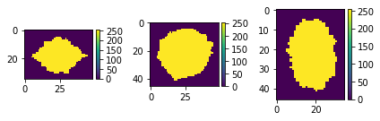

```python
cell = Cell(input_cell_kind='spiky_cell',
            input_voxel_size=0.3,
            size_x=7,
            size_y=7,
            size_z=10,
            phi=np.pi/4,
            theta=np.pi/2,
            spikiness=0.5,
            spike_size=1,
            spike_smoothness=0.05)
cell.show_2d_projections()
p3.clear()
p3.plot_isosurface(cell.image)
p3.show()
```

## Generating multicellular samples

To generate a multicellular sample one has to specify cell parameters (e.g. size and rotation) for each cell in the sample. This is done in two steps:

1. Cell parameters for each sample are specified as `pandas.DataFrame`, or as an instance of the class `CellParams`, where the cell parameters are generated randomly with specified mean and standard deviation.
2. Sample images are generated with a given voxel size.

### Generating parameters for a multicellular sample

```python
from DeconvTest import CellParams
print(CellParams.__init__.__doc__)
```

```
        Initializes the class for CellParams and generate random cell parameters with given properties.

        Keyword arguments:
        -----------
        input_cell_kind : string, optional
            Name of the shape of the ground truth object from set of
            {ellipsoid, spiky_cell}.
            Default is 'ellipsoid'
        number_of_stacks : int, optional
            Number of stacks to generate.
            If None, parameters for single cells will be generated
            Default is None.
        number_of_cells: int, optional
            Number of cells to generate.
            Default is 1.
        coordinates : bool, optional
            If True, relative cell coordinates will be generated.
            Default is True.
        kwargs : key, value pairings
            Further keyword arguments passed to corresponding methods to generate cell parameters.
```

#### Usage examples

##### Example 1

Generate random cell parameters for 5 spherical cells with diameters 10 $\pm$ 2 µm:

```python
params = CellParams(number_of_cells=5,
                    size_mean_and_std=(10, 2),
                    equal_dimensions=True)
params
```

|  | size_x | size_y | size_z | phi | theta | z | y | x | input_cell_kind |
| --- | --- | --- | --- | --- | --- | --- | --- | --- | --- |
| 0 | 10.622235 | 10.622235 | 10.622235 | 0 | 0 | 0.388699 | 0.632136 | 0.835086 | ellipsoid |
| 1 | 12.107066 | 12.107066 | 12.107066 | 0 | 0 | 0.041857 | 0.326144 | 0.739110 | ellipsoid |
| 2 | 6.425231 | 6.425231 | 6.425231 | 0 | 0 | 0.649720 | 0.077322 | 0.088054 | ellipsoid |
| 3 | 10.372747 | 10.372747 | 10.372747 | 0 | 0 | 0.400604 | 0.004007 | 0.168240 | ellipsoid |
| 4 | 8.690967 | 8.690967 | 8.690967 | 0 | 0 | 0.293970 | 0.204721 | 0.982759 | ellipsoid |

##### Example 2

Generate random cell parameters for 5 spiky ellipsoidal cells with axes sizes 10 $\pm$ 2 µm, spikiness from 0.1 to 1, spike size from 0.1 to 1 and spike smoothness from 0.05 to 0.07:

```python
params = CellParams(number_of_cells=5,
                    input_cell_kind='spiky_cell',
                    size_mean_and_std=(10, 2),
                    equal_dimensions=False,
                    spikiness_range=(0.1, 1),
                    spike_size_range=(0.1, 1),
                    spike_smoothness_range=(0.05, 0.07))
params
```

|  | size_x | size_y | size_z | phi | theta | spikiness | spike_size | spike_smoothness | z | y | x | input_cell_kind |
| --- | --- | --- | --- | --- | --- | --- | --- | --- | --- | --- | --- | --- |
| 0 | 9.559672 | 7.257061 | 8.199977 | 0.772193 | 2.343945 | 0.694482 | 0.535540 | 0.064830 | 0.315120 | 0.774142 | 0.128627 | spiky_cell |
| 1 | 10.642330 | 7.593122 | 13.448859 | 6.146339 | 1.786036 | 0.708266 | 0.839482 | 0.055717 | 0.850541 | 0.084370 | 0.697277 | spiky_cell |
| 2 | 5.333567 | 13.829871 | 9.653306 | 2.054071 | 1.876519 | 0.839661 | 0.883497 | 0.050711 | 0.258778 | 0.220791 | 0.967620 | spiky_cell |
| 3 | 7.237454 | 8.715542 | 13.131329 | 3.043581 | 0.247296 | 0.493759 | 0.539404 | 0.059861 | 0.143567 | 0.557877 | 0.034623 | spiky_cell |
| 4 | 10.629596 | 7.663825 | 11.718086 | 3.931058 | 1.331277 | 0.673595 | 0.336582 | 0.061777 | 0.060485 | 0.138157 | 0.165865 | spiky_cell |

Save the cell parameters into a csv file:

```python
params.save('code_examples/cell_parameters.csv')
```

Initialize a new class for cell parameters and read in the saved cell parameter:

```python
params2 = CellParams()
params2.read_from_csv('code_examples/cell_parameters.csv')
params2
```

|  | size_x | size_y | size_z | phi | theta | spikiness | spike_size | spike_smoothness | z | y | x | input_cell_kind |
| --- | --- | --- | --- | --- | --- | --- | --- | --- | --- | --- | --- | --- |
| 0 | 9.559672 | 7.257061 | 8.199977 | 0.772193 | 2.343945 | 0.694482 | 0.535540 | 0.064830 | 0.315120 | 0.774142 | 0.128627 | spiky_cell |
| 1 | 10.642330 | 7.593122 | 13.448859 | 6.146339 | 1.786036 | 0.708266 | 0.839482 | 0.055717 | 0.850541 | 0.084370 | 0.697277 | spiky_cell |
| 2 | 5.333567 | 13.829871 | 9.653306 | 2.054071 | 1.876519 | 0.839661 | 0.883497 | 0.050711 | 0.258778 | 0.220791 | 0.967620 | spiky_cell |
| 3 | 7.237454 | 8.715542 | 13.131329 | 3.043581 | 0.247296 | 0.493759 | 0.539404 | 0.059861 | 0.143567 | 0.557877 | 0.034623 | spiky_cell |
| 4 | 10.629596 | 7.663825 | 11.718086 | 3.931058 | 1.331277 | 0.673595 | 0.336582 | 0.061777 | 0.060485 | 0.138157 | 0.165865 | spiky_cell |

##### Example 3

Specify cell parameters as a `pandas.DataFrame`:

```python
import pandas as pd
params = pd.DataFrame({'size_x': [10, 10, 10],
                      'size_y': [9, 10, 8],
                      'size_z': [10, 11, 10],
                      'phi': [0, np.pi/4, np.pi/2],
                      'theta': [0, 0, 0],
                      'x': [0.1, 0.8, 0.2],
                      'y': [0.5, 0.5, 0.5],
                      'z': [0.2, 0.5, 0.8],
                       'input_cell_kind': 'spiky_cell',
                      'spikiness': [0, 0, 1],
                      'spike_size': [0, 0, 1],
                      'spike_smoothness': [0.05, 0.05, 0.05]})
params
```

|  | size_x | size_y | size_z | phi | theta | x | y | z | input_cell_kind | spikiness | spike_size | spike_smoothness |
| --- | --- | --- | --- | --- | --- | --- | --- | --- | --- | --- | --- | --- |
| 0 | 10 | 9 | 10 | 0.000000 | 0 | 0.1 | 0.5 | 0.2 | spiky_cell | 0 | 0 | 0.05 |
| 1 | 10 | 10 | 11 | 0.785398 | 0 | 0.8 | 0.5 | 0.5 | spiky_cell | 0 | 0 | 0.05 |
| 2 | 10 | 8 | 10 | 1.570796 | 0 | 0.2 | 0.5 | 0.8 | spiky_cell | 1 | 1 | 0.05 |

### Generating a multicellular sample from cell parameters

An image with multiple cells can be generated using the class `Stack`, which accepts the following arguments:

```python
from DeconvTest import Stack
print(Stack.__init__.__doc__)
```

```
        Initializes the Stack class.

        Parameters
        ----------
        filename: str, optional
            Path used to load the cell image.
            If None or non-existent, no image will be loaded.
            Default is None.
        input_voxel_size : scalar or sequence of scalars, optional
            Voxel size used to generate the stack.
            If None, no stack will be generated.
            Default is None.
        stack_size : sequence of scalars, optional
            Dimensions of the image stack in micrometers.
            If None, no stack will be generated.
            Default is None.
        cell_params : pandas.DataFrame or CellParams
            Dictionary of cell parameters.
            The columns should include the keyword arguments passed though `Cell.generate`.
            If None, no stack will be generated.
            Default is None.
```

#### Usage examples

##### Example 1

Generate a multicellular sample with voxel size 0.5 µm and dimensions 50 x 50 x 50 µm using the cell parameters defined in Example 3 of section 2.2.1.1:

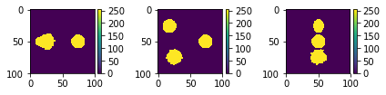

```python
stack = Stack(cell_params=params,
              input_voxel_size=0.5,
              stack_size=[50, 50, 50])
stack.show_2d_projections()
p3.clear()
p3.plot_isosurface(stack.image)
p3.show()
```

## Generating synthetic PSFs

PSF for multiphoton microscopy can be estimated to have a Gaussian shape, therefore we here generate PSFs as discretized 3D Gaussian functions. A PSF can be generated using the class `PSF`, which accept the following arguments:

```python
from DeconvTest import PSF
print(PSF.__init__.__doc__)
```

```
        Initializes the PSF image by reading from file or generating from given sigma and elongation

        Parameters
        ----------
        filename : str, optional
            Path used to load the PSF image.
            If None or non-existent, no image will be loaded.
            Default is None.
        kwargs : key, value pairings
            Keyword arguments passed to corresponding methods to generate synthetic PSFs.
```

### Usage examples

##### Example 1

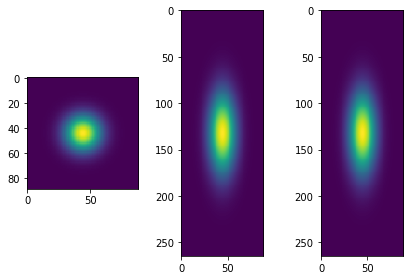

```python
psf = PSF(sigma=10,
          aspect_ratio=3)
psf.show_2d_projections()
```

## Convolving cells with PSFs

The microscopic imaging process is represented by convolution of a cell image with a PSF image.

### Usage examples

##### Example 1

Generate an image of an ellipsoidal cell with axes 10, 6, and 6 µm, rotation of π/4 along the polar axis and π/2 along the azimuthal axis, and the voxel size of 0.3 µm per px:

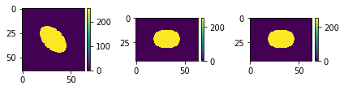

```python
cell = Cell(input_voxel_size=0.3,
            size=[10, 6, 6],
            phi=np.pi/4,
            theta=np.pi/2)
cell.show_2d_projections()
```

Generate a PSF image with standard deviation 0.5 µm in xy and 1.5 µm in z and voxel size 0.3 µm:

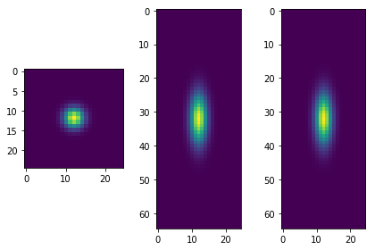

```python
psf = PSF(sigma=0.5/0.3,
          aspect_ratio=1.5/0.5)
psf.show_2d_projections()
```

Convolve the cell image with the PSF image:

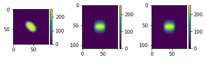

```python
cell.convolve(psf)
cell.show_2d_projections()
```

##### Example 2

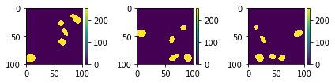

```python
params = CellParams(number_of_cells=6,
                    size_mean_and_std=(7, 2),
                    equal_dimensions=False)
stack = Stack(cell_params=params,
              input_voxel_size=0.5,
              stack_size=[50, 50, 50])
stack.show_2d_projections()
```

Convolve the sample image with the PSF image from Example 1:

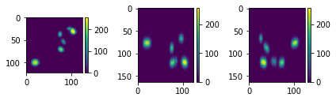

```python
stack.convolve(psf)
stack.show_2d_projections()
```

## Downsizing convolved images

The process of image discretization is simulated by downsizing the convolved cell images.

### Usage examples

##### Example 1

Downsize the convolved cell image from Example 1 of section 2.4.1 from voxel size 0.3 µm per px to voxel size 0.8 µm per px:

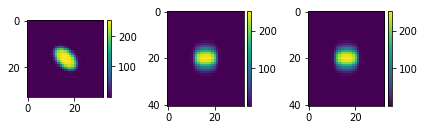

```python
cell.resize(zoom=0.3/0.8)
cell.show_2d_projections()
```

##### Example 2

Downsize the convolved stack image from Example 2 of section 2.4.1 from voxel size 0.5 µm per px to voxel size 0.8 µm per px in xy and 3 µm per px in z.

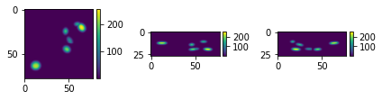

```python
stack.resize(zoom=[0.5/3, 0.5/0.8, 0.5/0.8])
stack.show_2d_projections()
```

## Adding synthetic noise

To investigate the influence of noise, Poisson or Gaussian noise of different signal-to-noise ratios (SNRs) can be added to the convolved and down-sampled images.

The SNR for the Gaussian noise is evaluated as follows:

$$\mathrm{SNR} = 20 \log_{10} \frac{I_{max}}{\sigma}$$

Here, $I_{max}$ is the maximum image intensity, which represents the signal amplitude; $\sigma$ is the standard deviation of the Gaussian noise, which represents the noise amplitude.

Hence, to add Gaussian noise of a given SNR, the noise amplitude $\sigma$ can be computed as follows: $$\sigma = \frac{I_{max}}{10^{\mathrm{SNR}/20}}$$

Then, for each pixel, a random number is drawn from the normal distribution with $\mu = 0$ and $\sigma = \sigma$ and is added to the value of this pixel.

The SNR of the Poisson distribution is evaluated as follows:

$$\mathrm{SNR} = \sqrt{I},$$

To generate the Poisson noise with a given SNR, the image is normalized such that its maximum value equals to $\mathrm{SNR}^2$. Then, each pixel's intensity is replaced by a random value from the Poisson distribution that has the expectation value equal to corresponding pixel intensity.

### Usage examples

##### Example 1

Add Poisson noise with SNR = 2 to the downsampled cells from Example 1 of section 2.5.1:

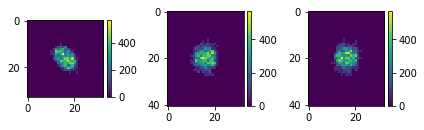

```python
cell.add_noise(snr=2,
               kind='poisson')
cell.show_2d_projections()
```

##### Example 2

Generate a spherical cell of size 10 µm and voxel size 0.3 µm per px and add Gaussian noise with SNR = 5:

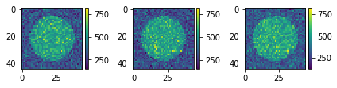

```python
cell = Cell(input_voxel_size=0.3,
            size=10)
cell.add_noise(snr=5,
               kind='gaussian')
cell.show_2d_projections()
```

##### Example 3

Generate a multicellular sample with 6 ellipoidal cells with axes sizes 7 $\pm$ 2 µm; sample dimensions 50 x 50 x 50 µm and voxel size 0.3 µm per px, and add Gaussian noise with SNR = 10 and then Poisson noise with SNR = 2:

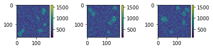

```python
params = CellParams(number_of_cells=6,
                    size_mean_and_std=(7, 2),
                    equal_dimensions=False)
stack = Stack(cell_params=params,
              input_voxel_size=0.3,
              stack_size=[50, 50, 50])
stack.add_noise(snr=[10, 2],
                kind=['gaussian', 'poisson'])
stack.show_2d_projections()
```

# Reconstructing synthetic data with different deconvolution approaches

The following Fiji plugins have so far been implemented in the DeconvTest framework.

- DeconvolutionLab2 (http://bigwww.epfl.ch/deconvolution/deconvolutionlab2/): Regularized Inverse Filter (RIF)
- DeconvolutionLab2: Richardson-Lucy with Total Variance (RLTV)
- Iterative Deconvolve 3D (DAMAS) (https://imagej.net/Iterative_Deconvolve_3D)

The plugins are run from python and thus can be easily incorporated in the analysis pipeline. The images of cells and PSF are loaded into the plugins from a corresponding tiff file.

## Preparing the images for deconvolution

Generate an image of an ellipsoidal cell with axes 10, 6, and 6 µm, rotation of π/4 along the polar axis and π/2 along the azimuthal axis, and the voxel size of 0.3 µm per px; save the image to a tif file and the image metadata to a csv file:

```
0
Voxel size             [0.3 0.3 0.3]
Voxel size z                     0.3
Voxel size y                     0.3
Voxel size x                     0.3
Voxel size arr         [0.3 0.3 0.3]
size                      [10, 6, 6]
phi               0.7853981633974483
theta             1.5707963267948966
kind                       ellipsoid
Convolved                      False
Name: 1, dtype: object
```

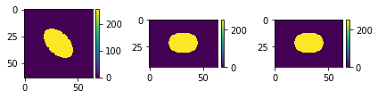

```python
cell = Cell(input_voxel_size=0.3,
            size=[10, 6, 6],
            phi=np.pi/4,
            theta=np.pi/2)
cell.save('code_examples/input_cell.tif')
cell.show_2d_projections()
pd.read_csv('code_examples/input_cell.csv', sep='\t', index_col=0, header=None).squeeze()
```

Generate a PSF image with standard deviation 0.5 µm in xy and 1.5 µm in z (elongation 3), voxel size 0.3 µm per px; save the PSF image to a tif file:

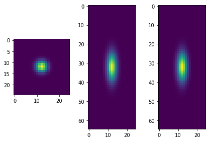

```python
psf = PSF(sigma=0.5 / 0.3,
          aspect_ratio=3)
psf.save('code_examples/psf.tif')
psf.show_2d_projections()
```

Convolve the cell image with the PSF image and save the result to a tif file:

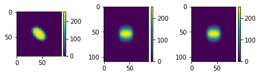

```python
cell.convolve(psf)
cell.save('code_examples/convolved_cell.tif')
cell.show_2d_projections()
```

Get the Fiji path and store it in a config file (this step is done automatically when installing the DeconvTest package):

```python
from DeconvTest.modules.deconvolution import get_fiji_path
imagej_path = get_fiji_path()
```

## DeconvolutionLab2: Regularized Inverse Filter (RIF)

RIF a simple deconvolution approach, which involves coefficient-wise division in the Fourier domain (see Sage *et al.* 2017 for detail). To penalize noise amplification, RIF involves a regularization parameter $\lambda$:

￼

[figure not shown]

D. Sage, L. Donati, F. Soulez, D. Fortun, G. Schmit, A. Seitz, R. Guiet, C. Vonesch, and M. Unser, “Decon- volutionLab2: An open-source software for deconvolution microscopy,” Methods 115, 28–41 (2017).

### Usage examples

##### Example 1

Deconvolve the previously stored cell image (Section 3.1) with the regularized inverse filter using $\lambda$ = 0.001:

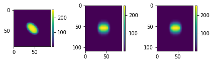

```python
import os
from DeconvTest.modules.deconvolution import deconvolution_lab_rif
deconvolution_lab_rif(imagej_path=imagej_path,
                      inputfile=os.getcwd() + '/code_examples/convolved_cell.tif',
                      psffile=os.getcwd() + '/code_examples/psf.tif',
                      regularization_lambda=0.001,
                      outputfile=os.getcwd() + '/code_examples/deconvolved_rif.tif')

cell = Cell(filename='code_examples/deconvolved_rif.tif')
cell.show_2d_projections()
```

## DeconvolutionLab2: Richardson-Lucy with Total Variance (RLTV)

RLTV is an iterative minimization approach, which -- similarly to RIF -- also involves regularization (see Sage *et al.* 2017 for detail). Thus, RLTV uses two parameters: the regularization $\lambda$ and the number of iterations:

￼

[figure not shown]

D. Sage, L. Donati, F. Soulez, D. Fortun, G. Schmit, A. Seitz, R. Guiet, C. Vonesch, and M. Unser, “Decon- volutionLab2: An open-source software for deconvolution microscopy,” Methods 115, 28–41 (2017).

### Usage examples

##### Example 1

Deconvolve the previously stored cell image (Section 3.1) with the Richardson-Lucy Total Variance algorithm using $\lambda$ = 0.001 and 5 iterations:

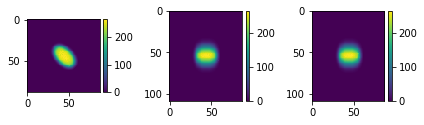

```python
from DeconvTest.modules.deconvolution import deconvolution_lab_rltv
deconvolution_lab_rltv(imagej_path=imagej_path,
                       inputfile=os.getcwd() + '/code_examples/convolved_cell.tif',
                       psffile=os.getcwd() + '/code_examples/psf.tif',
                       rltv_lambda=0.001,
                       iterations=5,
                       outputfile=os.getcwd() + '/code_examples/deconvolved_rltv.tif')

cell = Cell(filename='code_examples/deconvolved_rltv.tif')
cell.show_2d_projections()
```

## Iterative Deconvolve 3D (DAMAS)

DAMAS is an iterative deconvolution algorithm that includes multiple regularization techniques (see Dougherty *et al.* 2005 and the plugin documentation at http://www.optinav.info/Iterative-Deconvolve-3D.htm for details).

Six of the plugin's parameters can be adjusted from the DeconvTest framework:

- Normalize PSF (normalizes the PSF before deconvoltution)
- Detect divergence (stops the iteration if the changes in the image increase)
- Perform antiringing step (reduces artifacts from features close to the image border)
- Wiener filter $\gamma$ (regualization parameter)
- Low pass filter (regualization parameter)
- Terminate iteration if mean delta less than x% (stops the iteration if the changes in the image are less than the value of x)

￼

[figure not shown]

R. Dougherty, “Extensions of DAMAS and Benefits and Limitations of Deconvolution in Beamforming,” (American Institute of Aeronautics and Astronautics, 2005).

### Usage examples

##### Example 1

Deconvolve the previously stored cell image (Section 3.1) with the DAMAS algorithm using 2 iterations and the following parameters:

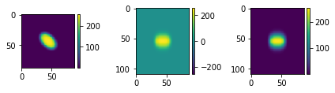

```python
from DeconvTest.modules.deconvolution import iterative_deconvolve_3d
iterative_deconvolve_3d(imagej_path=imagej_path,
                        inputfile=os.getcwd() + '/code_examples/convolved_cell.tif',
                        psffile=os.getcwd() + '/code_examples/psf.tif',
                        outputfile=os.getcwd() + '/code_examples/deconvolved_iterative.tif',
                        normalize=False,
                        perform=False,
                        detect=True,
                        wiener=0.0001,
                        low=3,
                        terminate=0.01,
                        iterations=2)

cell = Cell(filename='code_examples/deconvolved_iterative.tif')
cell.show_2d_projections()
```

# Quantification of deconvolution performance

After deconvolving synthetic images of cells, the performance of deconvolution can be quantified by comparing the images of reconstructed cells to the ground truth (initially generated cells) and computing the reconstruction errors. To quantify the reconstuction errors, the following two measures are computed:

1. Root-mean-square error (RMSE):

$$RMSE = \sqrt{\frac{\sum_{i=1}^{N} (y_i - x_i)^2}{N}},$$

where $x_i$ is the $i$-th pixel's value in the ground truth image, $y_i$ is the corresponding pixel value in the reconstructed image, and $N$ is the total number of pixels.

1. Normalized root-mean-square error (NRMSE):

$$NRMSE = \frac{RMSE}{x_{max} - x_{min}},$$

where $x_{max}$ and $x_{min}$ are the maximum and the minimum intensity values of the ground truth image, respectively.

## Usage examples

##### Example 1

Generate a cell, save it to a tiff file, and convolve it with a PSF:

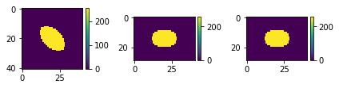

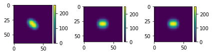

```python
cell = Cell(input_voxel_size=0.5,
            size=[10, 6, 6],
            phi=np.pi/4,
            theta=np.pi/2)
cell.show_2d_projections()
cell.save('code_examples/ground_truth_cell.tif')
psf = PSF(sigma=2,
          aspect_ratio=1.5)
cell.convolve(psf)
cell.show_2d_projections()
```

Compare the images of the cell before and after convolution:

```python
gt_cell = Cell(filename='code_examples/ground_truth_cell.tif')
cell.compute_accuracy_measures(gt_cell)
```

|  | RMSE | NRMSE |
| --- | --- | --- |
| 0 | 22.300309 | 0.087452 |

# Running DeconvTest in a batch mode

Simulation of microscopy experiments can be done in a batch mode, *i.e.* synthetic cells can be generated, convolved, deconvolved and quantified in a parallel manner. The number of processes that should be run in parallel is specified by the parameters `max_threads`. If the parameter `print_progress` is set to `True`, the progress of the computation and the remaining time will be printed out.

## Usage examples

##### Example 1: Generate single cells

Generate cell parameters for 3 ellipsoidal cells with axes 10 $\pm$ 2 µm:

```python
from DeconvTest import batch
batch.generate_cell_parameters(outputfile='code_examples/cell_parameters.csv',
                               number_of_cells=3,
                               size_mean_and_std=(10, 2),
                               equal_dimensions=False)
pd.read_csv('code_examples/cell_parameters.csv', sep='\t', index_col=0)
```

|  | size_x | size_y | size_z | phi | theta | z | y | x | input_cell_kind |
| --- | --- | --- | --- | --- | --- | --- | --- | --- | --- |
| 0 | 10.342048 | 7.540784 | 10.621244 | 5.222262 | 1.848282 | 0.212806 | 0.075437 | 0.648796 | ellipsoid |
| 1 | 8.530039 | 12.086726 | 7.791857 | 5.223985 | 2.325712 | 0.278137 | 0.339334 | 0.912768 | ellipsoid |
| 2 | 11.472264 | 9.833669 | 8.702283 | 1.231429 | 1.897113 | 0.338912 | 0.717907 | 0.915383 | ellipsoid |

Generate the cells with voxel size 0.2 µm per px running 4 processes in parallel:

```python
batch.generate_cells_batch(params_file='code_examples/cell_parameters.csv',
                           outputfolder='code_examples/input_cells',
                           input_voxel_size=0.2,
                           max_threads=4,
                           print_progress=True)
```

```
Run Generation of cells
Started at  Sat Nov 23 20:22:09 2019
done 1 of 3 ( 33.333333333333336 % ), approx. time left:  0.5394186973571777 sec
done 2 of 3 ( 66.66666666666667 % ), approx. time left:  0.1605837345123291 sec
done 3 of 3 ( 100.0 % ), approx. time left:  0.0 sec
Generation of cells done
```

Cell images are saved in the specified directory together with their metadata, which is stored in a csv file:

```python
sorted(os.listdir('code_examples/input_cells'))
```

```
['cell_000.csv',
 'cell_000.tif',
 'cell_001.csv',
 'cell_001.tif',
 'cell_002.csv',
 'cell_002.tif']
```

```python
pd.read_csv('code_examples/input_cells/cell_002.csv', sep='\t',
            index_col=0, header=None).transpose()
```

|  | Voxel size | Voxel size z | Voxel size y | Voxel size x | Voxel size arr | size_x | size_y | size_z | phi | theta | z | y | x | kind | Convolved | CellID |
| --- | --- | --- | --- | --- | --- | --- | --- | --- | --- | --- | --- | --- | --- | --- | --- | --- |
| 1 | [0.2 0.2 0.2] | 0.2 | 0.2 | 0.2 | [0.2 0.2 0.2] | 11.472263615296075 | 9.833669089581225 | 8.702282724036799 | 1.2314294955994782 | 1.8971128153188703 | 0.3389115175482139 | 0.7179073754119432 | 0.9153831848159096 | ellipsoid | False | 002 |

Generate 4 PSF images with resolution 0.2 µm per px and all combinations of given xy standard deviations and elongation:

```python
batch.generate_psfs_batch(outputfolder='code_examples/psfs',
                          psf_sigmas=[0.3, 1],
                          psf_aspect_ratios=[1.5, 4],
                          input_voxel_size=[0.2],
                          max_threads=4,
                          print_progress=False)
```

PSF images are saved in the specified directory together with their metadata:

```python
sorted(os.listdir('code_examples/psfs'))
```

```
['psf_sigma_0.3_aspect_ratio_1.5.csv',
 'psf_sigma_0.3_aspect_ratio_1.5.tif',
 'psf_sigma_0.3_aspect_ratio_4.csv',
 'psf_sigma_0.3_aspect_ratio_4.tif',
 'psf_sigma_1_aspect_ratio_1.5.csv',
 'psf_sigma_1_aspect_ratio_1.5.tif',
 'psf_sigma_1_aspect_ratio_4.csv',
 'psf_sigma_1_aspect_ratio_4.tif']
```

Convolve all input cells with all PSFs:

```python
batch.convolve_batch(inputfolder='code_examples/input_cells',
                     psffolder='code_examples/psfs',
                     outputfolder='code_examples/convolved',
                     max_threads=4,
                     print_progress=False)
```

For each PSF, a directory is generated where the convolved cells are stored. The PSF itself is also stored together with its metadata.

The output file structure is as follows:

- PSF 1 image
- PSF 1 metadata
- folder with convolution results for PSF 1
  - cell 1 image
  - cell 1 metadata
  - cell 2 image
  - cell 2 metadata
  - ...
- PSF 2 image
- PSF 2 metadata
- folder with convolution results for PSF 2
  - cell 1 image
  - cell 1 metadata
  - cell 2 image
  - cell 2 metadata
  - ...
- ...

```python
sorted(os.listdir('code_examples/convolved'))
```

```
['psf_sigma_0.3_aspect_ratio_1.5',
 'psf_sigma_0.3_aspect_ratio_1.5.csv',
 'psf_sigma_0.3_aspect_ratio_1.5.tif',
 'psf_sigma_0.3_aspect_ratio_4',
 'psf_sigma_0.3_aspect_ratio_4.csv',
 'psf_sigma_0.3_aspect_ratio_4.tif',
 'psf_sigma_1_aspect_ratio_1.5',
 'psf_sigma_1_aspect_ratio_1.5.csv',
 'psf_sigma_1_aspect_ratio_1.5.tif',
 'psf_sigma_1_aspect_ratio_4',
 'psf_sigma_1_aspect_ratio_4.csv',
 'psf_sigma_1_aspect_ratio_4.tif']
```

Each PSF directory contains convolution results for all input cells together with the metadata:

```python
sorted(os.listdir('code_examples/convolved/psf_sigma_1_aspect_ratio_1.5'))
```

```
['cell_000.csv',
 'cell_000.tif',
 'cell_001.csv',
 'cell_001.tif',
 'cell_002.csv',
 'cell_002.tif']
```

Resize the convolved cells to voxel sizes 0.5 µm in all axes, as well as 0.5 µm in xy and 1 µm in z:

```python
batch.resize_batch(inputfolder='code_examples/convolved',
                   outputfolder='code_examples/resized',
                   voxel_sizes_for_resizing=[0.5, [1, 0.5, 0.5]],
                   max_threads=4,
                   print_progress=False)
```

For each combination of voxel size and PSF, a new directory was created. PSF images are also resized. The output file structure is as follows:

- PSF 1, resolution 1: image
- PSF 1, resolution 1: metadata
- folder with resizing results for PSF 1, resolution 1
  - cell 1 image
  - cell 1 metadata
  - cell 2 image
  - cell 2 metadata
  - ...
- PSF 1, resolution 2: image
- PSF 1, resolution 2: metadata
- folder with resizing results for PSF 1, resolution 2
  - cell 1 image
  - cell 1 metadata
  - cell 2 image
  - cell 2 metadata
  - ...
- PSF 2, resolution 1: image
- PSF 2, resolution 1: metadata
- folder with resizing results for PSF 2, resolution 1
  - cell 1 image
  - cell 1 metadata
  - cell 2 image
  - cell 2 metadata
  - ...
- PSF 2, resolution 2: image
- PSF 2, resolution 2: metadata
- folder with resizing results for PSF 2, resolution 2
  - cell 1 image
  - cell 1 metadata
  - cell 2 image
  - cell 2 metadata
  - ...
- ...

```python
sorted(os.listdir('code_examples/resized'))
```

```
['psf_sigma_0.3_aspect_ratio_1.5_voxel_size_[0.5_0.5_0.5]',
 'psf_sigma_0.3_aspect_ratio_1.5_voxel_size_[0.5_0.5_0.5].csv',
 'psf_sigma_0.3_aspect_ratio_1.5_voxel_size_[0.5_0.5_0.5].tif',
 'psf_sigma_0.3_aspect_ratio_1.5_voxel_size_[1._0.5_0.5]',
 'psf_sigma_0.3_aspect_ratio_1.5_voxel_size_[1._0.5_0.5].csv',
 'psf_sigma_0.3_aspect_ratio_1.5_voxel_size_[1._0.5_0.5].tif',
 'psf_sigma_0.3_aspect_ratio_4_voxel_size_[0.5_0.5_0.5]',
 'psf_sigma_0.3_aspect_ratio_4_voxel_size_[0.5_0.5_0.5].csv',
 'psf_sigma_0.3_aspect_ratio_4_voxel_size_[0.5_0.5_0.5].tif',
 'psf_sigma_0.3_aspect_ratio_4_voxel_size_[1._0.5_0.5]',
 'psf_sigma_0.3_aspect_ratio_4_voxel_size_[1._0.5_0.5].csv',
 'psf_sigma_0.3_aspect_ratio_4_voxel_size_[1._0.5_0.5].tif',
 'psf_sigma_1_aspect_ratio_1.5_voxel_size_[0.5_0.5_0.5]',
 'psf_sigma_1_aspect_ratio_1.5_voxel_size_[0.5_0.5_0.5].csv',
 'psf_sigma_1_aspect_ratio_1.5_voxel_size_[0.5_0.5_0.5].tif',
 'psf_sigma_1_aspect_ratio_1.5_voxel_size_[1._0.5_0.5]',
 'psf_sigma_1_aspect_ratio_1.5_voxel_size_[1._0.5_0.5].csv',
 'psf_sigma_1_aspect_ratio_1.5_voxel_size_[1._0.5_0.5].tif',
 'psf_sigma_1_aspect_ratio_4_voxel_size_[0.5_0.5_0.5]',
 'psf_sigma_1_aspect_ratio_4_voxel_size_[0.5_0.5_0.5].csv',
 'psf_sigma_1_aspect_ratio_4_voxel_size_[0.5_0.5_0.5].tif',
 'psf_sigma_1_aspect_ratio_4_voxel_size_[1._0.5_0.5]',
 'psf_sigma_1_aspect_ratio_4_voxel_size_[1._0.5_0.5].csv',
 'psf_sigma_1_aspect_ratio_4_voxel_size_[1._0.5_0.5].tif']
```

Each directory contains corresponding cells with the metadata:

```python
sorted(os.listdir('code_examples/resized/psf_sigma_0.3_aspect_ratio_4_voxel_size_[1._0.5_0.5]'))
```

```
['cell_000.csv',
 'cell_000.tif',
 'cell_001.csv',
 'cell_001.tif',
 'cell_002.csv',
 'cell_002.tif']
```

Add Gaussian noise with SNRs 5 and 10 to all resized cells:

```python
batch.add_noise_batch(inputfolder='code_examples/resized',
                      outputfolder='code_examples/noise',
                      snr=[5, 10],
                      noise_kind='gaussian',
                      max_threads=4,
                      print_progress=False)
```

The output file structure is as follows:

- PSF 1, resoluton 1: image
- PSF 1, resoluton 1: metadata
- folder with convolution results for PSF 1, resoluton 1, SNR 1
  - cell 1 image
  - cell 1 metadata
  - cell 2 image
  - cell 2 metadata
  - ...
- folder with convolution results for PSF 1, resoluton 1, SNR 2
  - cell 1 image
  - cell 1 metadata
  - cell 2 image
  - cell 2 metadata
  - ...
- ...
- PSF 2, resoluton 2: image
- PSF 2, resoluton 2: metadata
- folder with convolution results for PSF 2, resoluton 2, SNR 1
  - cell 1 image
  - cell 1 metadata
  - cell 2 image
  - cell 2 metadata
  - ...
- folder with convolution results for PSF 2, resoluton 2, SNR 2
  - cell 1 image
  - cell 1 metadata
  - cell 2 image
  - cell 2 metadata
  - ...
- ...

```python
sorted(os.listdir('code_examples/noise'))[0:10]
```

```
['psf_sigma_0.3_aspect_ratio_1.5_voxel_size_[0.5_0.5_0.5].csv',
 'psf_sigma_0.3_aspect_ratio_1.5_voxel_size_[0.5_0.5_0.5].tif',
 'psf_sigma_0.3_aspect_ratio_1.5_voxel_size_[0.5_0.5_0.5]_noise_gaussian_snr=10',
 'psf_sigma_0.3_aspect_ratio_1.5_voxel_size_[0.5_0.5_0.5]_noise_gaussian_snr=5',
 'psf_sigma_0.3_aspect_ratio_1.5_voxel_size_[1._0.5_0.5].csv',
 'psf_sigma_0.3_aspect_ratio_1.5_voxel_size_[1._0.5_0.5].tif',
 'psf_sigma_0.3_aspect_ratio_1.5_voxel_size_[1._0.5_0.5]_noise_gaussian_snr=10',
 'psf_sigma_0.3_aspect_ratio_1.5_voxel_size_[1._0.5_0.5]_noise_gaussian_snr=5',
 'psf_sigma_0.3_aspect_ratio_4_voxel_size_[0.5_0.5_0.5].csv',
 'psf_sigma_0.3_aspect_ratio_4_voxel_size_[0.5_0.5_0.5].tif']
```

##### Example 2: generate multicellular samples

Generate parameters for samples with varying number of cells:

```python
batch.generate_cell_parameters(outputfile='code_examples/stack_parameters.csv',
                               number_of_stacks=3,
                               number_of_cells=[3, 5],
                               size_mean_and_std=(10, 2),
                               equal_dimensions=False)
pd.read_csv('code_examples/stack_parameters.csv', sep='\t', index_col=0)
```

|  | size_x | size_y | size_z | phi | theta | z | y | x | input_cell_kind | stack |
| --- | --- | --- | --- | --- | --- | --- | --- | --- | --- | --- |
| 0 | 8.434726 | 10.234011 | 7.660893 | 2.705187 | 1.367274 | 0.746544 | 0.198747 | 0.528852 | ellipsoid | 0 |
| 1 | 8.404471 | 8.079947 | 8.106322 | 3.340192 | 1.188578 | 0.206613 | 0.773662 | 0.645588 | ellipsoid | 0 |
| 2 | 16.066037 | 13.163236 | 7.372376 | 0.168824 | 2.767139 | 0.435277 | 0.409944 | 0.425916 | ellipsoid | 0 |
| 3 | 9.939774 | 10.901759 | 9.030953 | 4.639031 | 1.840216 | 0.767115 | 0.780256 | 0.655598 | ellipsoid | 0 |
| 4 | 8.586936 | 12.351030 | 10.890392 | 3.954106 | 0.572943 | 0.900957 | 0.859113 | 0.244108 | ellipsoid | 1 |
| 5 | 6.730910 | 12.148388 | 6.977474 | 5.519703 | 2.208111 | 0.683956 | 0.038275 | 0.347131 | ellipsoid | 1 |
| 6 | 13.859217 | 9.491067 | 11.429917 | 5.495994 | 1.029616 | 0.801981 | 0.125064 | 0.779321 | ellipsoid | 1 |
| 7 | 9.686063 | 10.714937 | 10.580438 | 6.227956 | 0.495953 | 0.809791 | 0.790994 | 0.922074 | ellipsoid | 1 |
| 8 | 8.403695 | 10.019205 | 12.752367 | 1.586155 | 0.508800 | 0.129551 | 0.621037 | 0.725749 | ellipsoid | 2 |
| 9 | 13.096508 | 6.722746 | 10.851751 | 5.352123 | 2.692592 | 0.838122 | 0.673539 | 0.394024 | ellipsoid | 2 |
| 10 | 9.325140 | 11.779813 | 10.229388 | 2.135610 | 2.340001 | 0.812708 | 0.672131 | 0.633409 | ellipsoid | 2 |
| 11 | 8.862764 | 13.684674 | 7.520243 | 4.468480 | 1.807637 | 0.861867 | 0.243643 | 0.438672 | ellipsoid | 2 |

Generate multicellular samples with voxel size 2 µm per px in z and 0.5 µm per px in xy:

```python
batch.generate_cells_batch(params_file='code_examples/stack_parameters.csv',
                           stack_size_microns=[60, 100, 100],
                           outputfolder='code_examples/input_stacks',
                           input_voxel_size=[2, 0.5, 0.5],
                           max_threads=4,
                           print_progress=False)
sorted(os.listdir('code_examples/input_stacks'))
```

```
['stack_000.csv',
 'stack_000.tif',
 'stack_001.csv',
 'stack_001.tif',
 'stack_002.csv',
 'stack_002.tif']
```

Generate PSFs with voxel size 2 µm per px in z and 0.5 µm per px in xy, standard deviation 0.3 µm in xy and elongation 1.5:

```python
batch.generate_psfs_batch(outputfolder='code_examples/psfs2',
                          psf_sigmas=[0.3],
                          psf_aspect_ratios=[1.5],
                          input_voxel_size=[2, 0.5, 0.5],
                          max_threads=4,
                          print_progress=False)
```

Convolve all input images with all PSFs:

```python
batch.convolve_batch(inputfolder='code_examples/input_stacks',
                     psffolder='code_examples/psfs2',
                     outputfolder='code_examples/stacks_convolved',
                     max_threads=4,
                     print_progress=False)
```

Resize the convolved images:

```python
batch.resize_batch(inputfolder='code_examples/stacks_convolved',
                   outputfolder='code_examples/stacks_resized',
                   voxel_sizes_for_resizing=[[3, 0.5, 0.5]],
                   max_threads=4,
                   print_progress=False)
```

Add Poisson noise to the resized images:

```python
batch.add_noise_batch(inputfolder='code_examples/stacks_resized',
                      outputfolder='code_examples/stacks_noise',
                      snr=[2],
                      noise_kind='poisson',
                      max_threads=4,
                      print_progress=False)
```

##### Example 3: run the full simulation on single cell images

Generate cell parameters, cells, PSFs, convolve the cells with the PSFs and add noise:

```python
batch.generate_cell_parameters(outputfile='code_examples/cell_parameters.csv',
                               number_of_cells=1,
                               size_mean_and_std=(8, 2),
                               equal_dimensions=False)
batch.generate_cells_batch(params_file='code_examples/cell_parameters.csv',
                           outputfolder='code_examples/input_cells_deconv',
                           input_voxel_size=0.3,
                           max_threads=4,
                           print_progress=False)
batch.generate_psfs_batch(outputfolder='code_examples/psfs_deconv',
                          psf_sigmas=[0.3], psf_aspect_ratios=[1.5],
                          input_voxel_size=[0.3],
                          max_threads=4,
                          print_progress=False)
batch.convolve_batch(inputfolder='code_examples/input_cells_deconv',
                     psffolder='code_examples/psfs_deconv',
                     outputfolder='code_examples/convolved_deconv',
                     max_threads=4,
                     print_progress=False)
batch.resize_batch(inputfolder='code_examples/convolved_deconv',
                  outputfolder='code_examples/resized_deconv',
                  voxel_sizes_for_resizing=[0.5],
                  max_threads=4,
                  print_progress=False)
batch.add_noise_batch(inputfolder='code_examples/resized_deconv',
                      outputfolder='code_examples/noise_deconv',
                      snr=[10],
                      noise_kind='poisson',
                      max_threads=4,
                      print_progress=False)
```

Deconvolve the generated cells with Regularize Inverse Filter and with Richardson-Lucy Total Variance algorithm, using two sets of parameters for each algorithm:

```python
batch.deconvolve_batch(inputfolder='code_examples/noise_deconv/',
                      outputfolder='code_examples/deconvolved/',
                      deconvolution_algorithm=['deconvolution_lab_rif', 'deconvolution_lab_rltv'],
                      deconvolution_lab_rif_regularization_labmda=[0.001, 0.002],
                      deconvolution_lab_rltv_regularization_labmda=[0.0001],
                      deconvolution_lab_rltv_iterations=[10, 15],
                      print_progress=False,
                      max_threads=4)
os.listdir('code_examples/deconvolved/')
```

```
['deconvolution_lab_rif_regularization_labmda=0.002',
 'deconvolution_lab_rltv_regularization_labmda=0.0001_iterations=10',
 'deconvolution_lab_rltv_regularization_labmda=0.0001_iterations=15',
 'deconvolution_lab_rif_regularization_labmda=0.001']
```

```python
os.listdir('code_examples/deconvolved/deconvolution_lab_rif_regularization_labmda=0.001')
```

```
['psf_sigma_0.3_aspect_ratio_1.5_voxel_size_[0.5_0.5_0.5]_noise_poisson_snr=10']
```

```python
os.listdir('code_examples/deconvolved/deconvolution_lab_rif_regularization_labmda=0.001/psf_sigma_0.3_aspect_ratio_1.5_voxel_size_[0.5_0.5_0.5]_noise_poisson_snr=10')
```

```
['cell_000.csv', 'cell_000.tif']
```

Compare the deconvolved images to the ground truth:

```python
batch.accuracy_batch(inputfolder='code_examples/deconvolved',
                     reffolder='code_examples/input_cells_deconv',
                     outputfolder='code_examples/accuracy',
                     max_threads=4,
                     print_progress=False)
```

All accuracy values are combined into a single csv file:

```python
pd.read_csv('code_examples/accuracy.csv', sep='\t', index_col=0)
```

|  | CellID | Convolved | Deconvolution algorithm | NRMSE | Name | PSF aspect ratio | PSF sigma xy um | RMSE | SNR | Voxel size | ... | noise type | phi | regularization_labmda | size_x | size_y | size_z | theta | x | y | z |
| --- | --- | --- | --- | --- | --- | --- | --- | --- | --- | --- | --- | --- | --- | --- | --- | --- | --- | --- | --- | --- | --- |
| 0 | 0.0 | True | deconvolution_lab_rif | 0.260275 | deconvolution_lab_rif_regularization_labmda=0.... | 1.5 | 0.3 | 66.370061 | 10.0 | [0.5 0.5 0.5] | ... | poisson | 2.371714 | 0.0020 | 6.770303 | 9.922441 | 8.722771 | 2.045996 | 0.913367 | 0.057857 | 0.094649 |
| 1 | 0.0 | True | deconvolution_lab_rltv | 0.123203 | deconvolution_lab_rltv_regularization_labmda=0... | 1.5 | 0.3 | 31.416859 | 10.0 | [0.5 0.5 0.5] | ... | poisson | 2.371714 | 0.0001 | 6.770303 | 9.922441 | 8.722771 | 2.045996 | 0.913367 | 0.057857 | 0.094649 |
| 2 | 0.0 | True | deconvolution_lab_rltv | 0.133348 | deconvolution_lab_rltv_regularization_labmda=0... | 1.5 | 0.3 | 34.003770 | 10.0 | [0.5 0.5 0.5] | ... | poisson | 2.371714 | 0.0001 | 6.770303 | 9.922441 | 8.722771 | 2.045996 | 0.913367 | 0.057857 | 0.094649 |
| 3 | 0.0 | True | deconvolution_lab_rif | 0.260275 | deconvolution_lab_rif_regularization_labmda=0.... | 1.5 | 0.3 | 66.370061 | 10.0 | [0.5 0.5 0.5] | ... | poisson | 2.371714 | 0.0010 | 6.770303 | 9.922441 | 8.722771 | 2.045996 | 0.913367 | 0.057857 | 0.094649 |

4 rows × 26 columns

# Running *in silico* deconvolution experiments with the "run_simulation" script

## Specifying parameters of the experiment

An *in silico* microscopy and deconvolution experiment can be run via executing a specifically developed script, which accepts the parameters of the experiment specified in a csv config file.

The following are the parameters and their default values (if any) used by the script:

| Parameter | Description | Default value |
| --- | --- | --- |
| simulation_folder | directory to save the simulation output | ./test_simulation |
| simulation_steps | list of simulation steps to run; valid values are: `generate_cells`, `generate_psfs`, `convolve`, `resize`, `add_noise`, `deconvolve`, `accuracy` | ['generate_cells', 'generate_psfs', 'convolve', 'resize', 'add_noise','deconvolve', 'accuracy'] |
| cell_parameter_filename | csv file name in the `simulation_folder` to save cell parameters | cell_parameters.csv |
| inputfolder | directory in the `simulation_folder` to save generated synthetic cells | input |
| psffolder | directory in the `simulation_folder` to save generated PSF images | psf |
| convolve_results_folder | directory in the `simulation_folder` to save the results of convolution of input cells with PSFs | convolved |
| resize_results_folder | directory in the `simulation_folder` to save the downsized images | resized |
| add_noise_results_folder | directory in the `simulation_folder` to save images after adding noise | noise |
| deconvolve_results_folder | directory in the `simulation_folder` to save deconvolved images | deconvolved |
| accuracy_results_folder | directory in the `simulation_folder` to save the deconvolution performance results | accuracy_measures |
| log_folder | directory in the `simulation_folder` to store computing time | timelog |
| max_threads | the maximal number of processes to run in parallel | 4 |
| print_progress | if True, the progress of the computation will be printed | True |
| number_of_stacks | number of multicellular samples to generate; if `None`, no multicellular samples will be generated, but only single cells | None |
| number_of_cells | number of single cells to generate or number of cells per each multicellular stack; if a range is indicated, and the `number_of_stacks` parameter is not `None`, a random number will be chosen from thi… | 2 |
| input_cell_kind | type the input cell to generate; valid values are: `ellipsoid`, `spiky_cell` | ellipsoid |
| size_mean_and_std | mean value and standard deviation for the cell size in micrometers; the cell size is drawn randomly from a Gaussian distribution with the given mean and standard deviation. | (10, 2) |
| equal_dimensions | if True, input cells will be generated as spheres; if False, input cells will be generated as ellipsoids with sizes for all three axes chosen independently | False |
| spikiness_range | range for the fraction of cell surface area covered by spikes (if `input_cell_kind` is `spiky_cell`) |  |
| spike_size_range | range for the standard deviation for the spike amplitude relative to the cell radius (if `input_cell_kind` is `spiky_cell`) |  |
| spike_smoothness_range | range for the width of the Gaussian filter that is used to smooth the spikes (if `input_cell_kind` is `spiky_cell`) |  |
| input_voxel_size | voxel size in z, y and x used to generate the cell image; if one value is provided, the voxel size is assume to be equal along all axes. | 0.3 |
| stack_size_microns | dimensions of the multicellular image stack in micrometers | [10, 100, 100] |
| psf_sigmas | standard deviation(s) of the PSF in xy in micrometers; a PSF image will be generated for each combination of the provided values of `psf_sigmas` and `psf_aspect_ratios` | [0.1, 0.5] |
| psf_aspect_ratios | PSF aspect ratios; a PSF image will be generated for each combination of the provided values of `psf_sigmas` and `psf_aspect_ratios` | [3] |
| voxel_sizes_for_resizing | list of new voxel sizes to which the input images should be resized; each item of the list is a scalar (for the same voxels size along all axes) or sequence of scalars (voxel size in z, y and x) | [[1, 0.5, 0.5]] |
| noise_kind | type of noise to add; valid values are: `poisson`, `gaussian`; if several values are provided, all noise types will be added in the given order; if the same number of values are provided for `noise_ki… | [poisson] |
| snr | target signal-to-noise ratio (SNR) value(s); for each provided value, a new image will be generated; if several values for `noise_kind` are provided, and the same nuber of values are provided for `snr… | [None, 5] |
| test_snr_combinations | if `True`, and several values are provided for the `noise_kind` parameter and `snr` parameter, all combinations of given SNRs will be used for all provided noise types (e.g. if `noise_kind` is [`poiss… | False |
| deconvolution_algorithm | deconvolution algorithm(s) that will be applied to deconvolve the input images; if a sequence of algorithms is provided, all algorithms from the sequence will be applied | [deconvolution_lab_rif, deconvolution_lab_rltv] |
| log_computing_time | if True, computing time spent on deconvolution will be recorded and stored in the `log_folder` | True |
| deconvolution_lab_rif_regularization_lambda | regularization parameter for the RIF algorithm; if a sequence is provided, all values from the sequence will be tested | [0.001, 1] |
| deconvolution_lab_rltv_regularization_lambda | regularization parameter for the RLTV algorithm; if a sequence is provided, all values from the sequence will be tested in combination with the `iterations` parameter | 0.001 |
| deconvolution_lab_rltv_iterations | number of iterations in the RLTV algorithm; if a sequence is provided, all values from the sequence will be tested in combination with the `rltv_lambda` parameter | [2, 3] |
| iterative_deconvolve_3d_normalize | `Normalize PSF` parameter for the Iterative Deconvolve 3D plugin; if a sequence is provided, all values from the sequence will be tested in combination with other parameters |  |
| iterative_deconvolve_3d_perform | `Perform anti-ringig step` parameter for the Iterative Deconvolve 3D plugin; if a sequence is provided, all values from the sequence will be tested in combination with other parameters |  |
| iterative_deconvolve_3d_detect | `Detect divergence` parameter for the Iterative Deconvolve 3D plugin; if a sequence is provided, all values from the sequence will be tested in combination with other parameters |  |
| iterative_deconvolve_3d_wiener | `Wiener filter gamma` parameter for the Iterative Deconvolve 3D plugin; <0.0001 to turn off, 0.0001 - 0.1 as tests; if a sequence is provided, all values from the sequence will be tested in combinatio… |  |
| iterative_deconvolve_3d_low | `Low pass filter` parameter for the Iterative Deconvolve 3D plugin, pixels; the same value is used for low pass filter in xy and z; if a sequence is provided, all values from the sequence will be test… |  |
| iterative_deconvolve_3d_terminate | `Terminate iteration if mean delta < x%` parameter for the Iterative Deconvolve 3D plugin; 0 to turn off; if a sequence is provided, all values from the sequence will be tested in combination with oth… |  |

The parameter file does not have to specify all parameter values, but only those that should be different from the default values. This is how an example parameter file may look like:

```python
pd.read_csv('example_config_file.csv', sep='\t', index_col=0, header=None).squeeze()
```

```
0
simulation_folder                                                      ../../../Data/simulation1
max_threads                                                                                    3
simulation_steps                               ['generate_cells', 'generate_psfs', 'convolve'...
cell_parameter_filename                                                      cell_parameters.csv
number_of_cells                                                                                5
input_cell_kind                                                                       spiky_cell
input_voxel_size                                                                             0.3
spikiness_range                                                                       (0.5, 0.6)
psf_aspect_ratios                                                                          [4.5]
psf_sigmas                                                                                   [1]
voxel_sizes_for_resizing                                                    [0.3, [1, 0.3, 0.3]]
deconvolution_algorithm                                                    deconvolution_lab_rif
deconvolution_lab_rif_regularization_lambda                                         [0.001, 001]
Name: 1, dtype: object
```

## Running the experiment with the "run_simulation" script

To run a deconvolution experiment with specified settings, the `run_simulation.py` scipt should be copied to the directory of choice, and the following command should be executed:

`python run_simulation.py <settings_file>`

After the simulation is completed, the computed accuracy will be summarized in a csv file named the same as the `accuracy_results_folder` specified in the config file.

## Running DeconvTest with external synthetic data

DeconvTest can also be used with externally generated synthetic images.

### Usage examples

##### Example 1

Generate synthetic images with the software of your choice. Here is an example how this can be done using the DeconvolutionLab2 plugin of Fiji:

￼

[figure not shown]

Generate synthetic PSF images. For instance, with DeconvolutionLab2 you can generate an Airy-disk-shaped PSF:

￼

[figure not shown]

We generated two images with random lines and one airy-disk PSF and saved them in the folders 'data/synthetic/input/' and 'data/synthetic/psf/', respectively:

```python
os.listdir('data/synthetic/input')
```

```
['RandomLines1.tif', 'RandomLines2.tif']
```

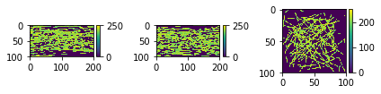

```python
stack = Stack(filename='data/synthetic/input/RandomLines1.tif')
stack.show_2d_projections()
```

```python
os.listdir('data/synthetic/psf')
```

```
['psf_airy.tif']
```

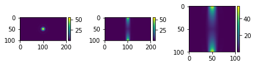

```python
psf = PSF(filename='data/synthetic/psf/psf_airy.tif')
psf.show_2d_projections()
```

As the next step, we need to create a metadata file with voxel size values for each image. Let's set voxel size to 1 µm in all dimensions:

```python
from DeconvTest.classes.metadata import Metadata
for fn in os.listdir('data/synthetic/input/'):
    md = Metadata()
    md.set_voxel_size(1)
    md.to_csv('data/synthetic/input/' + fn[:-4] + '.csv', sep='\t', header=False)
```

For the PSF image, the size of the PSF needs to be stored in the metadata file. Since this value is only used to group the quantification results, any value can be provided. Moreover, `isPSF` parameter has to be set to `True` to indicate that we don't want to deconvolve this image during the deconvolution step.

```python
for fn in os.listdir('data/synthetic/psf/'):
    md = Metadata()
    md.set_voxel_size(1)
    md['PSF sigma xy um'] = 1
    md['PSF aspect ratio'] = 1
    md['isPSF'] = 1
    md.to_csv('data/synthetic/psf/' + fn[:-4] + '.csv', sep='\t', header=False)
```

This is how the resulting metadata file looks like:

```python
pd.read_csv('data/synthetic/psf/psf_airy.csv', sep='\t', index_col=0, header=None).squeeze()
```

```
0
Voxel size          [1. 1. 1.]
Voxel size z               1.0
Voxel size y               1.0
Voxel size x               1.0
Voxel size arr      [1. 1. 1.]
PSF sigma xy um              1
PSF aspect ratio             1
isPSF                        1
Name: 1, dtype: object
```

Now, let's generate a configuration file to run DeconvTest workflow with these images. We will convolve the synthetic images and the PSF, add Poisson noise with SNR=5 and deconvolve the resulting data with two different values of the RIF $\lambda$:

```python
config = pd.Series({'simulation_folder': 'data/synthetic/',
                    'simulation_steps': ['convolve', 'add_noise','deconvolve', 'accuracy'],
                    'max_threads': 1,
                    'noise_kind': ['poisson'],
                    'snr': [5],
                    'test_snr_combinations': False,
                    'deconvolution_algorithm': ['deconvolution_lab_rif'],
                    'deconvolution_lab_rif_regularization_lambda': [0.001, 1]
                    })
config.to_csv('config_external_data.csv', sep='\t', header=False)
config
```

```
simulation_folder                                                          data/synthetic/
simulation_steps                               [convolve, add_noise, deconvolve, accuracy]
max_threads                                                                              1
noise_kind                                                                       [poisson]
snr                                                                                    [5]
test_snr_combinations                                                                False
deconvolution_algorithm                                            [deconvolution_lab_rif]
deconvolution_lab_rif_regularization_lambda                                     [0.001, 1]
dtype: object
```

Next, we run DeconvTest using this configuration file:

```python
%run run_simulation.py config_external_data.csv
```

```
Run the step 'convolve'
Input folder: data/synthetic/input Output folder: data/synthetic/convolved
Run Convolution
Started at  Sat Nov 23 20:22:52 2019
done 1 of 2 ( 50.0 % ), approx. time left:  2.616804599761963 sec
done 2 of 2 ( 100.0 % ), approx. time left:  0.0 sec
Convolution done
Run the step 'add_noise'
Input folder: data/synthetic/convolved Output folder: data/synthetic/noise
Run Add noise
Started at  Sat Nov 23 20:22:58 2019
done 1 of 3 ( 33.333333333333336 % ), approx. time left:  2.3192248344421387 sec
done 2 of 3 ( 66.66666666666667 % ), approx. time left:  1.0852831602096558 sec
done 3 of 3 ( 100.0 % ), approx. time left:  0.0 sec
Add noise done
Run the step 'deconvolve'
Input folder: data/synthetic/noise Output folder: data/synthetic/deconvolved
Run Deconvolve
Started at  Sat Nov 23 20:23:00 2019
done 1 of 6 ( 16.666666666666668 % ), approx. time left:  1.9963355263074238 min
done 2 of 6 ( 33.333333333333336 % ), approx. time left:  1.5492371956507365 min
done 3 of 6 ( 50.0 % ), approx. time left:  1.1429373264312743 min
done 4 of 6 ( 66.66666666666667 % ), approx. time left:  45.04067528247833 sec
done 5 of 6 ( 83.33333333333333 % ), approx. time left:  18.0279598236084 sec
done 6 of 6 ( 100.0 % ), approx. time left:  0.0 sec
Deconvolve done
Run the step 'accuracy'
Input folder: data/synthetic/deconvolved Output folder: data/synthetic/accuracy_measures
Reference folder: data/synthetic/deconvolved
Run Compute accuracy measures
Started at  Sat Nov 23 20:24:30 2019
done 1 of 4 ( 25.0 % ), approx. time left:  19.2667293548584 sec
done 2 of 4 ( 50.0 % ), approx. time left:  12.755794525146484 sec
done 3 of 4 ( 75.0 % ), approx. time left:  6.276400248209637 sec
done 4 of 4 ( 100.0 % ), approx. time left:  0.0 sec
Compute accuracy measures done
```

Let's now look at the resulting accuracy measures and plot the NRMSE depending on the value of RIF $\lambda$:

```python
accuracy = pd.read_csv('data/synthetic/accuracy_measures.csv', sep='\t')
accuracy
```

|  | Unnamed: 0 | Convolved | Deconvolution algorithm | NRMSE | Name | PSF aspect ratio | PSF sigma xy um | RMSE | SNR | Voxel size | Voxel size arr | Voxel size x | Voxel size y | Voxel size z | noise type | regularization_lambda |
| --- | --- | --- | --- | --- | --- | --- | --- | --- | --- | --- | --- | --- | --- | --- | --- | --- |
| 0 | 0 | True | deconvolution_lab_rif | 149.833538 | deconvolution_lab_rif_regularization_lambda=1.... | 1.0 | 1.0 | 53.829678 | 5.0 | [1. 1. 1.] | [1. 1. 1.] | 1.0 | 1.0 | 1.0 | poisson | 1.000 |
| 1 | 1 | True | deconvolution_lab_rif | 144.858149 | deconvolution_lab_rif_regularization_lambda=1.... | 1.0 | 1.0 | 55.850574 | 5.0 | [1. 1. 1.] | [1. 1. 1.] | 1.0 | 1.0 | 1.0 | poisson | 1.000 |
| 2 | 2 | True | deconvolution_lab_rif | 792.756149 | deconvolution_lab_rif_regularization_lambda=0.... | 1.0 | 1.0 | 106.241340 | 5.0 | [1. 1. 1.] | [1. 1. 1.] | 1.0 | 1.0 | 1.0 | poisson | 0.001 |
| 3 | 3 | True | deconvolution_lab_rif | 631.433266 | deconvolution_lab_rif_regularization_lambda=0.... | 1.0 | 1.0 | 99.508128 | 5.0 | [1. 1. 1.] | [1. 1. 1.] | 1.0 | 1.0 | 1.0 | poisson | 0.001 |

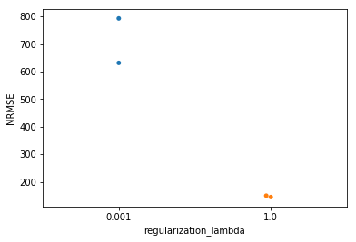

```python
import seaborn as sns
sns.swarmplot(data=accuracy, x='regularization_lambda', y='NRMSE')
```

It seems like the RIF $\lambda$ value of 1 worked much better for these data than the value of 0.001.

## Running DeconvTest with external deconvolution results

Synthetic microscopy images generated with DeconvTest can be deconvolved using external software and evaluated for deconvolution errors using DeconvTest.

### Usage examples

##### Example 1

First, we need to create a configuration file to generate synthetic images. Let's generate two ellipsoidal cells, convolve them with PSF, downsample, and add Poisson noise of SNR 5:

```python
config = pd.Series({'simulation_folder': 'data/ext_deconvolution/',
                    'simulation_steps': ['generate_cells', 'generate_psfs', 'convolve', 'resize', 'add_noise'],
                    'max_threads': 1,
                    'number_of_cells': 2,
                    'input_cell_kind': 'ellipsoid',
                    'input_voxel_size': 0.3,
                    'psf_sigmas': [0.5],
                    'psf_aspect_ratios': [4],
                    'voxel_sizes_for_resizing': [0.5],
                    'noise_kind': ['poisson'],
                    'snr': [5]
                    })
config.to_csv('config_external_deconv.csv', sep='\t', header=False)
config
```

```
simulation_folder                                     data/ext_deconvolution/
simulation_steps            [generate_cells, generate_psfs, convolve, resi...
max_threads                                                                 1
number_of_cells                                                             2
input_cell_kind                                                     ellipsoid
input_voxel_size                                                          0.3
psf_sigmas                                                              [0.5]
psf_aspect_ratios                                                         [4]
voxel_sizes_for_resizing                                                [0.5]
noise_kind                                                          [poisson]
snr                                                                       [5]
dtype: object
```

```python
%run run_simulation.py config_external_deconv.csv
```

```
Run the step 'generate_cells'
Generating new cell parameters
Output filedata/ext_deconvolution/cell_parameters.csv
Generating cells
Input file: data/ext_deconvolution/cell_parameters.csv Output folder: data/ext_deconvolution/input
Run Generation of cells
Started at  Sat Nov 23 20:25:00 2019
done 1 of 2 ( 50.0 % ), approx. time left:  0.1070709228515625 sec
done 2 of 2 ( 100.0 % ), approx. time left:  0.0 sec
Generation of cells done
Run the step 'generate_psfs'
Output folder: data/ext_deconvolution/psf
Run Generation of PSFs
Started at  Sat Nov 23 20:25:00 2019
done 1 of 1 ( 100.0 % ), approx. time left:  0.0 sec
Generation of PSFs done
Run the step 'convolve'
Input folder: data/ext_deconvolution/input Output folder: data/ext_deconvolution/convolved
Run Convolution
Started at  Sat Nov 23 20:25:00 2019
done 1 of 2 ( 50.0 % ), approx. time left:  0.30812501907348633 sec
done 2 of 2 ( 100.0 % ), approx. time left:  0.0 sec
Convolution done
Run the step 'resize'
Input folder: data/ext_deconvolution/convolved Output folder: data/ext_deconvolution/resized
Run Resize
Started at  Sat Nov 23 20:25:01 2019
done 1 of 3 ( 33.333333333333336 % ), approx. time left:  0.31549596786499023 sec
done 2 of 3 ( 66.66666666666667 % ), approx. time left:  0.159232497215271 sec
done 3 of 3 ( 100.0 % ), approx. time left:  0.0 sec
Resize done
Run the step 'add_noise'
Input folder: data/ext_deconvolution/resized Output folder: data/ext_deconvolution/noise
Run Add noise
Started at  Sat Nov 23 20:25:01 2019
done 1 of 3 ( 33.333333333333336 % ), approx. time left:  0.2144641876220703 sec
done 2 of 3 ( 66.66666666666667 % ), approx. time left:  0.11081743240356445 sec
done 3 of 3 ( 100.0 % ), approx. time left:  0.0 sec
Add noise done
```

This resulted in generating two synthetic microscopy images and corresponding PSFs:

```python
os.listdir('data/ext_deconvolution/noise')
```

```
['psf_sigma_0.5_aspect_ratio_4.0_voxel_size_[0.5_0.5_0.5].tif',
 'psf_sigma_0.5_aspect_ratio_4.0_voxel_size_[0.5_0.5_0.5].csv',
 'psf_sigma_0.5_aspect_ratio_4.0_voxel_size_[0.5_0.5_0.5]_noise_poisson_snr=5.0']
```

```python
os.listdir('data/ext_deconvolution/noise/psf_sigma_0.5_aspect_ratio_4.0_voxel_size_[0.5_0.5_0.5]_noise_poisson_snr=5.0')
```

```
['cell_001.csv', 'cell_001.tif', 'cell_000.csv', 'cell_000.tif']
```

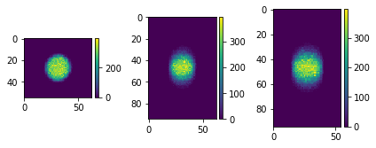

```python
psf = Stack(filename='data/ext_deconvolution/noise/psf_sigma_0.5_aspect_ratio_4.0_voxel_size_[0.5_0.5_0.5]_noise_poisson_snr=5.0/cell_001.tif')
psf.show_2d_projections()
```

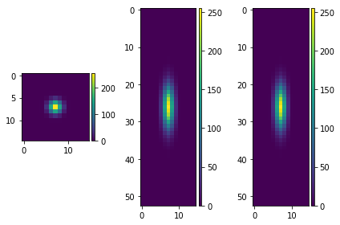

```python
psf = PSF(filename='data/ext_deconvolution/noise/psf_sigma_0.5_aspect_ratio_4.0_voxel_size_[0.5_0.5_0.5].tif')
psf.show_2d_projections()
```

As the next step, the generated images can be deconvolved with external software. For instance, here we deconvolved them with the Landweber algorithm from DeconvolutionLab2, which is not yet integrated into DeconvTest:

￼

[figure not shown]

The user should make sure that the structure of the deconvolution output corresponds to the structure generated by a DeconvTest workflow. Thus, deconvolution results from each parameter combination should be kept in a separate folder (here we applied two different values of the parameter $\gamma$):

```python
os.listdir('data/ext_deconvolution/deconvolved')
```

```
['Landweber_gamma=1', 'Landweber_gamma=0.1']
```

Each of these folders should contain a subfolder for each PSF/noise combination with the same naming as used before deconvolution:

```python
os.listdir('data/ext_deconvolution/deconvolved/Landweber_gamma=1')
```

```
['psf_sigma_0.5_aspect_ratio_4.0_voxel_size_[0.5_0.5_0.5]_noise_poisson_snr=5.0']
```

The subfolders contain the deconvolved images along with their metadata files:

```python
os.listdir('data/ext_deconvolution/deconvolved/Landweber_gamma=1/psf_sigma_0.5_aspect_ratio_4.0_voxel_size_[0.5_0.5_0.5]_noise_poisson_snr=5.0')
```

```
['cell_001.csv', 'cell_001.tif', 'cell_000.csv', 'cell_000.tif']
```

The metadata files can be generated by copying the corresponding files before deconvolution and adding the values of the deconvolution parameters (in this case, Landweber gamma):

```python
pd.read_csv('data/ext_deconvolution/deconvolved/Landweber_gamma=1/psf_sigma_0.5_aspect_ratio_4.0_voxel_size_[0.5_0.5_0.5]_noise_poisson_snr=5.0/cell_000.csv', sep='\t', index_col=0, header=None).squeeze()
```

```
0
Convolved                        True
Voxel size              [0.5 0.5 0.5]
Voxel size z                      0.5
Voxel size y                      0.5
Voxel size x                      0.5
Voxel size arr          [0.5 0.5 0.5]
size_x               12.2202971186863
size_y                11.302124005864
size_z               11.5728292920448
phi                  5.16113849690512
theta                1.15527948928779
z                   0.267924706436403
y                   0.015359300731685
x                   0.155969596604871
kind                        ellipsoid
CellID                              0
PSF sigma xy um                   0.5
PSF aspect ratio                    4
SNR                                 5
noise type                    poisson
LW gamma                            1
Name: 1, dtype: object
```

Once this is done, we can specify another configuration file for running the quantification step of DeconvTest:

```python
config = pd.Series({'simulation_folder': 'data/ext_deconvolution/',
                    'simulation_steps': ['accuracy'],
                    'max_threads': 1,
                    'inputfolder': 'deconvolved',
                    'reffolder': 'input'
                    })
config.to_csv('config_external_deconv_accuracy.csv', sep='\t', header=False)
config
```

```
simulation_folder    data/ext_deconvolution/
simulation_steps                  [accuracy]
max_threads                                1
inputfolder                      deconvolved
reffolder                              input
dtype: object
```

```python
%run run_simulation.py config_external_deconv_accuracy.csv
```

```
Run the step 'accuracy'
Input folder: data/ext_deconvolution/deconvolved Output folder: data/ext_deconvolution/accuracy_measures
Reference folder: data/ext_deconvolution/input
Run Compute accuracy measures
Started at  Sat Nov 23 20:25:07 2019
done 1 of 4 ( 25.0 % ), approx. time left:  0.9212672710418701 sec
done 2 of 4 ( 50.0 % ), approx. time left:  1.0692863464355469 sec
done 3 of 4 ( 75.0 % ), approx. time left:  0.45969223976135254 sec
done 4 of 4 ( 100.0 % ), approx. time left:  0.0 sec
Compute accuracy measures done
```

Let's now look at the resulting accuracy measures and plot the NRMSE depending on the value of Landweber $\gamma$ :

```python
accuracy = pd.read_csv('data/ext_deconvolution/accuracy_measures.csv', sep='\t')
accuracy
```

|  | Unnamed: 0 | CellID | Convolved | LW gamma | NRMSE | Name | PSF aspect ratio | PSF sigma xy um | RMSE | SNR | ... | kind | noise type | phi | size_x | size_y | size_z | theta | x | y | z |
| --- | --- | --- | --- | --- | --- | --- | --- | --- | --- | --- | --- | --- | --- | --- | --- | --- | --- | --- | --- | --- | --- |
| 0 | 0 | 1.0 | True | 1.0 | 0.233872 | Landweber_gamma=1/psf_sigma_0.5_aspect_ratio_4... | 4.0 | 0.5 | 59.637282 | 5.0 | ... | ellipsoid | poisson | 4.609668 | 7.812153 | 5.721329 | 7.123903 | 2.972010 | 0.992599 | 0.640824 | 0.840501 |
| 1 | 1 | 0.0 | True | 1.0 | 0.281557 | Landweber_gamma=1/psf_sigma_0.5_aspect_ratio_4... | 4.0 | 0.5 | 71.797018 | 5.0 | ... | ellipsoid | poisson | 5.161138 | 12.220297 | 11.302124 | 11.572829 | 1.155279 | 0.155970 | 0.015359 | 0.267925 |
| 2 | 2 | 1.0 | True | 0.1 | 0.219763 | Landweber_gamma=0.1/psf_sigma_0.5_aspect_ratio... | 4.0 | 0.5 | 56.039561 | 5.0 | ... | ellipsoid | poisson | 4.609668 | 7.812153 | 5.721329 | 7.123903 | 2.972010 | 0.992599 | 0.640824 | 0.840501 |
| 3 | 3 | 0.0 | True | 0.1 | 0.180290 | Landweber_gamma=0.1/psf_sigma_0.5_aspect_ratio... | 4.0 | 0.5 | 45.974065 | 5.0 | ... | ellipsoid | poisson | 5.161138 | 12.220297 | 11.302124 | 11.572829 | 1.155279 | 0.155970 | 0.015359 | 0.267925 |

4 rows × 25 columns

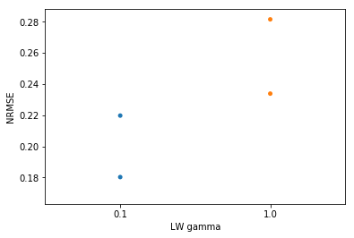

```python
import seaborn as sns
sns.swarmplot(data=accuracy, x='LW gamma', y='NRMSE')
```